## Towards an evidence-based Strategic Management for Sustainability: rethinking the measure of the outcome of healthy living in G20 nations post-2015. A reproducible research

**GLOBAL SUSTAINABILITY STRATEGY** **New models and approaches to achieve sustainable living** **14th ABIS ANNUAL COLLOQUIUM 2015**

### Stefano Olgiati, PhD, MS (1), Alessandro Danovi, MS (2)

1. Author Responsible For Correspondence: University of Bergamo , Department of Quantitative Methods, via dei Caniana 2, Bergamo (ITA) 24129; tel +39 035 20 52 638; fax +39 035 20 52 549; email stefano.olgiati@unibg.it
2. University of Bergamo, Faculty of Economics, Bergamo (ITA) 24129

**NOTICE TO FELLOW RESEARCHERS: THE WHO AS OF JULY 18, 2015, HAS UPDATED SOME DATABASES UTILIZED AS RAW DATA FOR THE TIDY DATASETS AND THE STATISTICAL INFERENCE. ACCORDINGLY, AFTER RUNNING THE PRESENT PROGRAM SOME OF THE NUMERIC FINDINGS MAY SLIGHTLY DIFFER FROM THE FINDINGS REPORTED IN THE SUBMISSION TO 14th ABIS ANNUAL COLLOQUIUM 2015. THE AUTHORS HAVE CHOSEN NOT TO “FREEZE” THE ORIGINAL DATA SOURCE BUT TO ALLOW AUTOMATIC UPDATING OF THE RESEARCH FINDINGS IN THE HTML DOCUMENT. THIS CAN BE VERIFIED BY THE > dateDownloaded CODE IN R. THIS IS A FURTHER ADVANTAGE IN TERMS OF TRANSPARENCY OF RESEARCH REPRODUCIBILITY. THANK YOU. THE AUTHORS**

### Raw Data

We utilized open access data from:

Institute for Health Metrics and Evaluation (IHME) Global Burden of Disease Study 2010 GHDx;

### Code Book

The following variables and definitions, based on “The Global Burden of Disease: Generating Evidence, Guiding Policy” and the World Health Organization’s Data Repository on Health Expenditure, were adopted when extracting the tidy data set from the raw data:

- Life Expectancy (LE): Life Expectancy at birth is the average number of years that a person can be expected to live from age 0-1;
- Health Adjusted Life Expectancy (HALE): Healthy Life Expectancy is the average number of years that a person can be expected to live in “full health”, by taking into account years lived in less than full health with disease and/or non-fatal injury ;
- Years Lived with Disability (YLD): The Years Lived with Disability is the difference between LE and HALE, where LE is always greater than or equal to HALE. It is equivalent to the number of years that people live with a health condition or its consequences or in less than full health with disease and/or non-fatal injury;

### Raw Data

Downloading data from the repositories

```r
# Getting raw data from the IHME Global Burden of Disease Study 2010
fileURL.GBD <- "http://ghdx.healthmetricsandevaluation.org/sites/default/files/record-attached-files/IHME_GBD_2010_HALE_BY_COUNTRY_1990_2010_Y2010M02D23.CSV"

download.file(fileURL.GBD, destfile="RawData/GBD.csv")

dateDownloaded <- date()
dateDownloaded
```

```
## [1] "Mon May 25 14:38:27 2015"
```

Reading raw data in .csv format

```r
# Raw Data
raw.data.GBD <- read.csv("RawData/GBD.csv")
names(raw.data.GBD)
```

```
## [1] "iso3"         "country_name" "year"         "age_name"
## [5] "sex_name"     "le"           "le_ui"        "hale"
## [9] "hale_ui"
```

```r
dim(raw.data.GBD)
```

```
## [1] 50490     9
```

```r
# Data Tables
attach(raw.data.GBD)

DT.GBD <- data.table(raw.data.GBD)

tables()
```

```
##      NAME     NROW NCOL MB
## [1,] DT.GBD 50,490    9  4
##      COLS                                                           KEY
## [1,] iso3,country_name,year,age_name,sex_name,le,le_ui,hale,hale_ui
## Total: 4MB
```

### Tidy Data Set

Manipulating data to generate tidy datasets

```r
# ISO 13 codes of G20 Countries for 1990/95 - 2010
# Argentina, Australia, Brazil, Canada, China, India, Indonesia, Japan, Mexico, Russia, Saudi Arabia, South Africa, South Korea, Turkey, the United Kingdom and the United States, European Union (EU)

ISO13 <- c("ARG", "AUS", "BRA", "CAN","CHN","IND","IDN","JPN","MEX","RUS","SAU","ZAF","KOR","TUR","USA", "AUT","BEL","BGR","HRV","CYP","CZE","DNK","EST","FIN","FRA","DEU","GRC","HUN","IRL","ITA","LVA","LTU","LUX","MLT","NLD","POL","PRT","ROU","SVK","SVN","ESP","SWE","GBR")

length(ISO13)
```

```
## [1] 43
```

```r
data.GBD.1990 <- DT.GBD[DT.GBD$year == "1990" & DT.GBD$age_name == "0-1 years" & DT.GBD$sex_name == "Both" & DT.GBD$iso3 %in% ISO13 , ]
data.GBD.1990.ordered <- data.GBD.1990[order(ISO13), ]

data.GBD.2010 <- DT.GBD[DT.GBD$year == "2010" & DT.GBD$age_name == "0-1 years" & DT.GBD$sex_name == "Both" & DT.GBD$iso3 %in% ISO13 , ]
data.GBD.2010.ordered <- data.GBD.2010[order(ISO13), ]

data.1990 <- data.frame(country=data.GBD.1990.ordered$iso3, le=data.GBD.1990.ordered$le, hale=data.GBD.1990.ordered$hale)

data.2010 <- data.frame(country=data.GBD.2010.ordered$iso3, le=data.GBD.2010.ordered$le, hale=data.GBD.2010.ordered$hale)

# Years Lived with Disease in G20 Countries for 1990 - 2010
yld.1990 <- data.1990$le - data.1990$hale
yld.2010 <- data.2010$le - data.2010$hale

# Tidy Dataset
tidy.data <- data.frame(country=data.2010$country, le_1990=data.1990$le,  le_2010=data.2010$le, hale_1990 = data.1990$hale, hale_2010 = data.2010$hale, yld_1990=yld.1990, yld_2010=yld.2010)
tidy.data
```

```
##    country le_1990 le_2010 hale_1990 hale_2010 yld_1990 yld_2010
## 1      ARG  72.543  75.957    63.164    66.114    9.379    9.843
## 2      AUS  76.869  81.501    66.420    70.096   10.449   11.405
## 3      FRA  77.067  80.927    66.519    69.484   10.548   11.443
## 4      GBR  75.651  79.906    65.427    68.624   10.224   11.282
## 5      GRC  76.919  79.582    66.509    68.668   10.410   10.914
## 6      AUT  75.708  80.612    65.787    69.134    9.921   11.478
## 7      BEL  75.916  79.531    65.733    68.542   10.183   10.989
## 8      BGR  71.386  73.526    62.495    64.103    8.891    9.423
## 9      HUN  69.381  74.472    60.191    64.247    9.190   10.225
## 10     IDN  64.969  69.723    56.170    60.882    8.799    8.841
## 11     KOR  72.132  79.714    63.843    70.301    8.289    9.413
## 12     IND  58.299  65.213    49.751    56.200    8.548    9.013
## 13     TUR  67.100  74.361    57.563    63.851    9.537   10.510
## 14     IRL  74.827  79.926    65.244    68.868    9.583   11.058
```

[output cut: 29 more lines]

```r
attach(tidy.data)

# Saving Tidy Dataset to .csv file
write.csv(tidy.data, "YLDOutput.csv")
```

### Exploratory Data Analysis

```r
# Data for background and rationale
summary(le_1990)
```

```
##    Min. 1st Qu.  Median    Mean 3rd Qu.    Max.
##   58.30   70.38   74.01   72.92   76.39   79.10
```

```r
mad(le_1990)
```

```
## [1] 4.311401
```

```r
skewness(le_1990)
```

```
## [1] -1.072556
```

```r
kurtosis(le_1990)
```

```
## [1] 1.367472
```

```r
summary(le_2010)
```

```
##    Min. 1st Qu.  Median    Mean 3rd Qu.    Max.
##   59.90   74.93   78.91   77.08   80.20   82.65
```

```r
mad(le_2010)
```

```
## [1] 3.621992
```

```r
skewness(le_2010)
```

```
## [1] -1.657332
```

```r
kurtosis(le_2010)
```

```
## [1] 3.158325
```

```r
summary(yld_1990)
```

```
##    Min. 1st Qu.  Median    Mean 3rd Qu.    Max.
##   7.570   9.156   9.689   9.693  10.220  11.550
```

```r
mad(yld_1990)
```

```
## [1] 0.793191
```

```r
skewness(yld_1990)
```

```
## [1] -0.07590112
```

```r
kurtosis(yld_1990)
```

```
## [1] -0.06595592
```

```r
summary(yld_2010)
```

```
##    Min. 1st Qu.  Median    Mean 3rd Qu.    Max.
##   7.948   9.850  10.510  10.480  11.290  12.780
```

```r
mad(yld_2010)
```

```
## [1] 1.144567
```

```r
skewness(yld_2010)
```

```
## [1] -0.3214347
```

```r
kurtosis(yld_2010)
```

```
## [1] -0.4445563
```

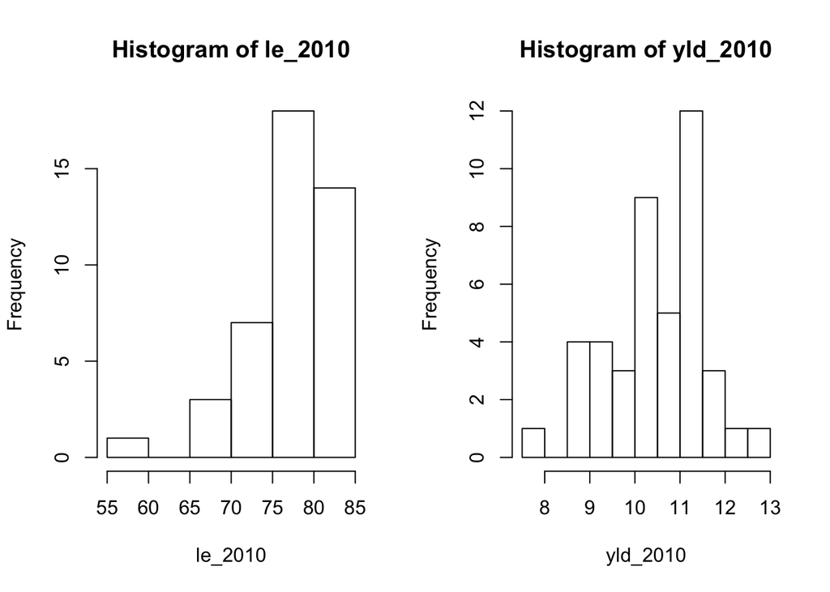

```r
# PLOTS
par(mfrow=c(1,2))
hist(le_2010)
hist(yld_2010)
```

```r
# Strip Charts
par(mfrow=c(1,2))
strip.data.1 <- data.frame(le_1990, le_2010)
stripchart(strip.data.1,
           vertical=TRUE,
           col=1:2,
           method="jitter")
abline(h=c(median(le_1990), median(le_2010)),
       col=1:2)
summary(strip.data.1)
```

```
##     le_1990         le_2010
##  Min.   :58.30   Min.   :59.90
##  1st Qu.:70.38   1st Qu.:74.93
##  Median :74.01   Median :78.91
##  Mean   :72.92   Mean   :77.08
##  3rd Qu.:76.39   3rd Qu.:80.20
##  Max.   :79.10   Max.   :82.65
```

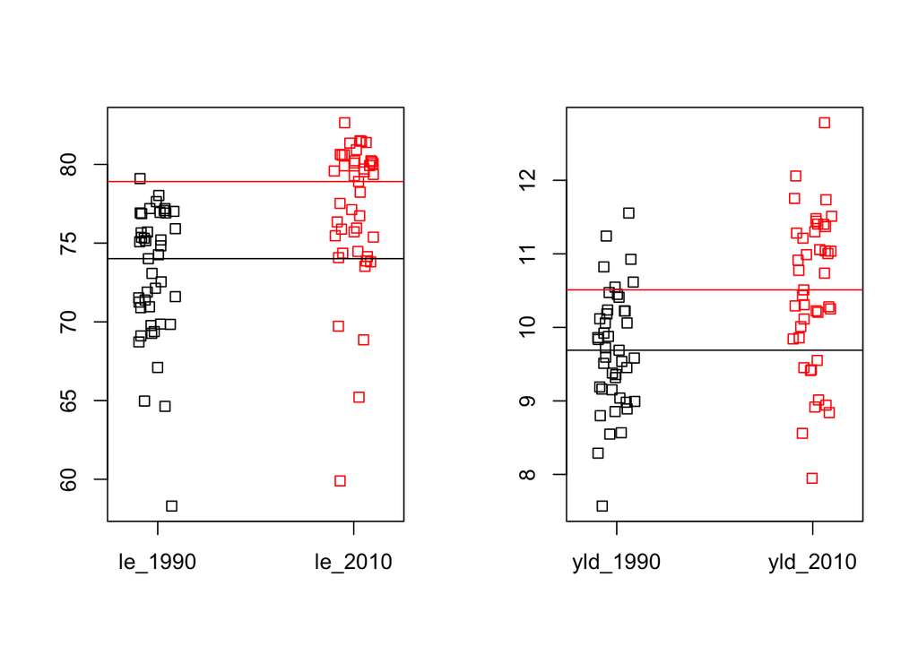

```r
strip.data.2 <- data.frame(yld_1990, yld_2010)
stripchart(strip.data.2,
           vertical=TRUE,
           col=1:2,
           method="jitter")
abline(h=c( median(yld_1990), median(yld_2010)),
       col=1:2)
```

```r
summary(strip.data.2)
```

```
##     yld_1990         yld_2010
##  Min.   : 7.570   Min.   : 7.948
##  1st Qu.: 9.156   1st Qu.: 9.851
##  Median : 9.689   Median :10.510
##  Mean   : 9.693   Mean   :10.481
##  3rd Qu.:10.223   3rd Qu.:11.291
##  Max.   :11.555   Max.   :12.783
```

### Model and Multiple Linear Regression

```r
# Linear regression
par(mfrow=c(1,2))

model1 <- lm(yld_1990 ~ le_1990)
plot(le_1990, yld_1990)
abline(model1, col = "red")
summary(model1)
```

```
##
## Call:
## lm(formula = yld_1990 ~ le_1990)
##
## Residuals:
##      Min       1Q   Median       3Q      Max
## -1.68539 -0.30416  0.05876  0.32284  1.73071
##
## Coefficients:
##             Estimate Std. Error t value Pr(>|t|)
## (Intercept)  0.93944    1.68069   0.559    0.579
## le_1990      0.12005    0.02301   5.217 5.56e-06 ***
## ---
## Signif. codes:  0 '***' 0.001 '**' 0.01 '*' 0.05 '.' 0.1 ' ' 1
##
## Residual standard error: 0.6357 on 41 degrees of freedom
## Multiple R-squared:  0.399,  Adjusted R-squared:  0.3843
## F-statistic: 27.22 on 1 and 41 DF,  p-value: 5.562e-06
```

```r
confint(model1)
```

```
##                   2.5 %    97.5 %
## (Intercept) -2.45478341 4.3336707
## le_1990      0.07357869 0.1665167
```

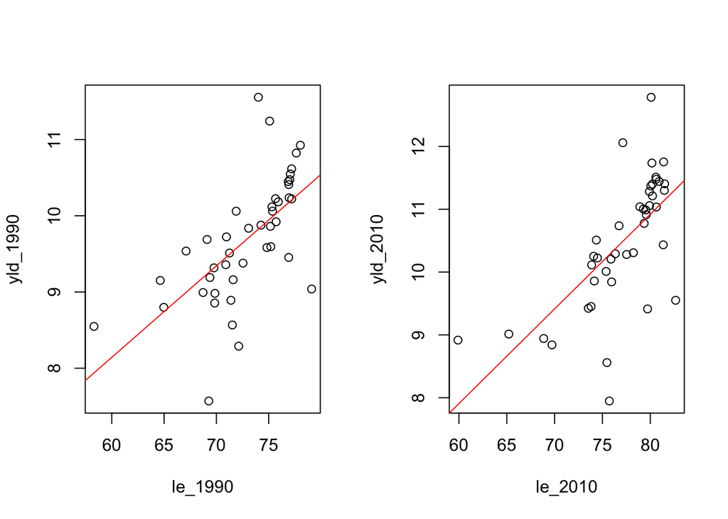

```r
model2 <- lm(yld_2010 ~ le_2010)
plot(le_2010, yld_2010)
abline(model2, col = "red")
```

```r
summary(model2)
```

```
##
## Call:
## lm(formula = yld_2010 ~ le_2010)
##
## Residuals:
##     Min      1Q  Median      3Q     Max
## -2.3278 -0.2837  0.1387  0.3788  1.8489
##
## Coefficients:
##             Estimate Std. Error t value Pr(>|t|)
## (Intercept) -1.13537    2.03363  -0.558     0.58
## le_2010      0.15070    0.02634   5.722 1.07e-06 ***
## ---
## Signif. codes:  0 '***' 0.001 '**' 0.01 '*' 0.05 '.' 0.1 ' ' 1
##
## Residual standard error: 0.7858 on 41 degrees of freedom
## Multiple R-squared:  0.444,  Adjusted R-squared:  0.4304
## F-statistic: 32.74 on 1 and 41 DF,  p-value: 1.075e-06
```

```r
confint(model2)
```

```
##                   2.5 %    97.5 %
## (Intercept) -5.24236813 2.9716275
## le_2010      0.09751467 0.2038939
```

```r
# 95% CI in month
slope <- model2$coefficients[2]
slopeInMonths <- slope * 12
slopeInMonths
```

```
##  le_2010
## 1.808451
```

```r
lower <- confint(model2)[2]
lowerInMonths <- lower * 12
lowerInMonths
```

```
## [1] 1.170176
```

```r
upper <- confint(model2)[4]
upperInMonths <- upper * 12
upperInMonths
```

```
## [1] 2.446727
```